# Assignment 2

Mateusz Baryła

4/6/2022

# Breaking Bad - the first season. Insights on the viewership.

## Brief description of the show

As (“List of Breaking Bad episodes - Wikipedia” 2022) stated, *Breaking Bad* is an American television drama series created by Vince Gilligan, which premiered in 2008 on the cable network AMC. The story is about Walter White (Bryan Cranston), a 50-year-old high school chemistry teacher in Albuquerque, New Mexico. After White is diagnosed with terminal lung cancer, he uses his chemistry expertise to cook crystal meth, assisted by his former student Jesse Pinkman (Aaron Paul), to secure his family’s (played by Anna Gunn and RJ Mitte) inheritance before he dies.

During the course of the series, 62 episodes of Breaking Bad aired over five seasons. The pilot episode was first aired on January 20, 2008, and the series finale, was broadcast on September 29, 2013. Breaking Bad: Original Minisodes, which consisted several one- to five-minute clips, released 17 short episodes over the course of three years throughout Breaking Bad’s run (“Snow Globe: A Breaking Bad Short Gives Us More of Todd from El Camino” 2022).

On October 11, 2019, Netflix released El Camino: A Breaking Bad Movie, a feature film continuation of Breaking Bad, written and directed by Gilligan (“‘Breaking Bad’ Movie, Starring Aaron Paul, Coming to Netflix in October - The New York Times” 2022). An additional short film Snow Globe: A Breaking Bad Short was released on February 17, 2020 (“’Breaking Bad’ Has 17 Secret Episodes Most Fans Don’t Know About” 2022).

[figure not shown]

## Loading data and presenting basic statistics

```r
load("../Data/bb_season_1.RData")
bb_season_data %>% head(3) %>% kableExtra::kable() %>% kableExtra::kable_styling()
```

| no_overall | no_season | title | directed_by | written_by | original_air_date | us_viewers |
| --- | --- | --- | --- | --- | --- | --- |
| 1 | 1 | Pilot | Vince Gilligan | Vince Gilligan | 2008-01-20 | 1.41 |
| 2 | 2 | Cat’s in the Bag… | Adam Bernstein | Vince Gilligan | 2008-01-27 | 1.49 |
| 3 | 3 | …And the Bag’s in the River | Adam Bernstein | Vince Gilligan | 2008-02-10 | 1.08 |

Firstly, we present the first three rows of the dataset.

```r
summary(bb_season_data$us_viewers)
```

```
##    Min. 1st Qu.  Median    Mean 3rd Qu.    Max.
##   0.970   1.075   1.090   1.230   1.450   1.500
```

In order to build preliminary insights of what’s hidden in the dataset we provide the summary of some basic statistics on viewership in USA. It revealed that this distribution is positively skewed. Having done that, we can gracefully move to the visualization part.

## Visualization

Showing viewership over time is a great way to built an intuition towards the dataset.

### Viewership over time

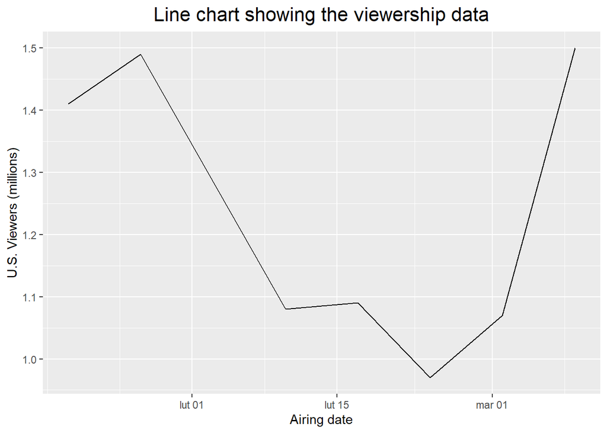

```r
bb_season_data %>%
  ggplot(aes(x = original_air_date, y = us_viewers)) +
  geom_line() +
  labs(x = "Airing date",
       y = "U.S. Viewers (millions)",
       title = "Line chart showing the viewership data") +
  report_theme
```

The plot above shows that there were a few changes in viewership. Both positive and negative fluctuations are visible. From this perspective they might seem significant, nevertheless the relative change in percentage points might create better insights.

### Episode-to-episode change in viewership

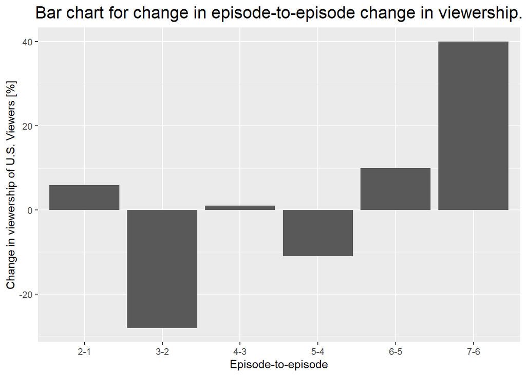

```r
change_in_viewership <- bb_season_data %>%
  mutate(episode_to_episode_change_in_viewership = round(100*(us_viewers - lag(us_viewers))/lag(us_viewers)),
         episode_to_episode = paste0(as.character(no_season), "-", as.character(lag(no_season)))) %>%
  filter(!is.na(episode_to_episode_change_in_viewership))
max_decrease <- change_in_viewership %>% pull(episode_to_episode_change_in_viewership) %>% min()
min_change <- change_in_viewership %>%
  mutate(episode_to_episode_change_in_viewership = abs(episode_to_episode_change_in_viewership)) %>% pull(episode_to_episode_change_in_viewership) %>%
  min()
change_in_viewership %>%
  ggplot(aes(x = episode_to_episode, y = episode_to_episode_change_in_viewership)) +
  geom_col() +
  labs(x = "Episode-to-episode",
       y = "Change in viewership of U.S. Viewers [%]",
       title = "Bar chart for change in episode-to-episode change in viewership.") +
  report_theme
```

The biggest decrease of -28 % has been seen between 3rd and 2nd episodes. On the other hand, the most remarkable peak in the viewership is associated with 7th and 6th components of the TV series. Considering the smallest relative difference it’s equal to 1.

# References

“’Breaking Bad’ Has 17 Secret Episodes Most Fans Don’t Know About.” 2022. https://www.cheatsheet.com/entertainment/breaking-bad-17-secret-episodes-fans-dont-know-about.html/.

“‘Breaking Bad’ Movie, Starring Aaron Paul, Coming to Netflix in October - The New York Times.” 2022. https://www.nytimes.com/2019/08/24/arts/television/breaking-bad-movie-starring-aaron-paul-coming-to-netflix-in-october.html.

“List of Breaking Bad episodes - Wikipedia.” 2022. https://en.wikipedia.org/wiki/List_of_Breaking_Bad_episodes.

“Snow Globe: A Breaking Bad Short Gives Us More of Todd from El Camino.” 2022. https://movieweb.com/snow-globe-breaking-bad-short-todd-el-camino/.